# DATA-413/613 Final Project: Vignette

Author

Chris Cioffi, Emily Eames, Mimi Beckemeier, Youssouf Barry

# 1 Senate Race FEC Helper

## 1.1 Use Case

This app will be used by U.S. voters hoping to get a better understanding of whether their candidate is raising money from their own neighbors and constituents, or if it’s donors from out of state seeking to influence an election. The app can also be used by journalists, campaign transparency watchdogs or people in foreign countries seeking to get an easy-to-understand readout of what’s happening in Senate elections in 2026.

##Required Packages

This app requires functionalities from the following packages:

- shiny
- tidyverse
- keyring
- httr2
- jsonlite
- plotly
- DT

## 1.2 Data Source and Structure

The Shiny app relies on two main functions to queries the FEC API in order to obtain donor information about Senate candidates running in states that have a Senate election in 2026. It gets user input on what states the user wants more information about a given candidate and then queries the https://api.open.fec.gov/v1/candidates/totals/ endpoint to get a list of all candidates in that state.

It then takes that list of candidates and queries the https://api.open.fec.gov/v1/schedules/schedule_a/by_state/by_candidate/ endpoint to pull down the donor and candidate stats about the candidates.

```r
fetch_candidate_fundraising <- function(list_candidates) {
  # Set the base URL for the FEC API
  base_url_for_candidate_fundraising <- "https://api.open.fec.gov/v1/schedules/schedule_a/by_state/by_candidate/"
  # Initialize an empty list to store results
  all_data <- list()
  # Iterate through each candidate ID in the dataframe
  for (candidate_id in list_candidates$candidate_id) { # Use the candidate_id column from list_candidates
    # Define query parameters for the current candidate
    params_candidate_fundraising <- list(
      per_page = 100,
      candidate_id = candidate_id,
      cycle = 2026,
      election_full = TRUE,
      sort = "state",
      api_key = keyring::key_get("fec_api_key") # Securely retrieve API key
    )
    # Try to fetch data for the current candidate
    tryCatch(
      {
        state_locations <- (request(base_url_for_candidate_fundraising) |>
                              req_url_query(!!!params_candidate_fundraising) |>
                              req_perform() |>
                              resp_body_json(resp = _))$results |>
          tibble(data = _) |>
          unnest_wider(data)
        # Add a column identifying the candidate
        state_locations$candidate_id <- candidate_id
        # Append to the results list
        all_data[[candidate_id]] <- state_locations
      },
      error = function(e) {
        message(paste("Error fetching data for candidate:", candidate_id))
      }
    )
  }
  # Combine all data into a single dataframe
  final_data <- bind_rows(all_data)
  # make sure the candidate name, party, etc is associated with each line
  final_data <- list_candidates |>
    select(name, candidate_id) |>
    right_join(final_data, by = "candidate_id")
  return(final_data)
}
```

## 1.3 EDA Inputs, Controls, and Outputs

Both queries return dataframes that include character and number columns with stats such as the candidate’s name, id, their total receipts, the reciepts from pacs, from indificual donors and their party. The data is broken down by state and the size of the dataframe depends on how many states were selected, which then, in-turn changes the number of candidates.

The users can select states that they want to examine and then will be provided the dataframes that are auto-generated based on their queries.

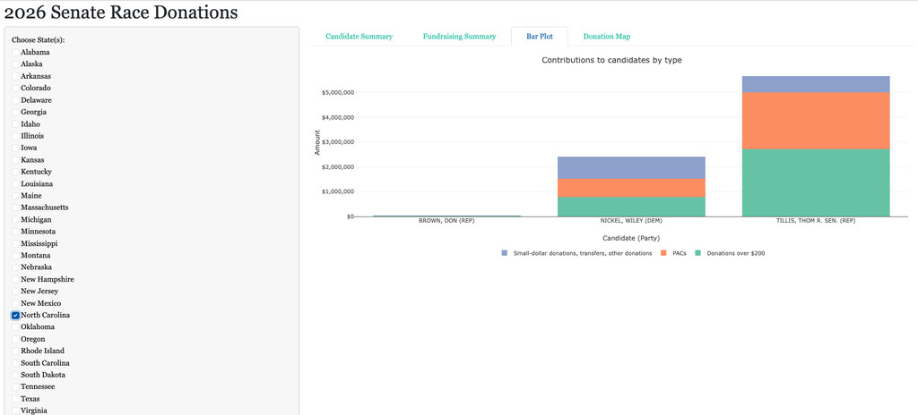

Example of the UI with states selected and the basic candidate stats auto-generated.

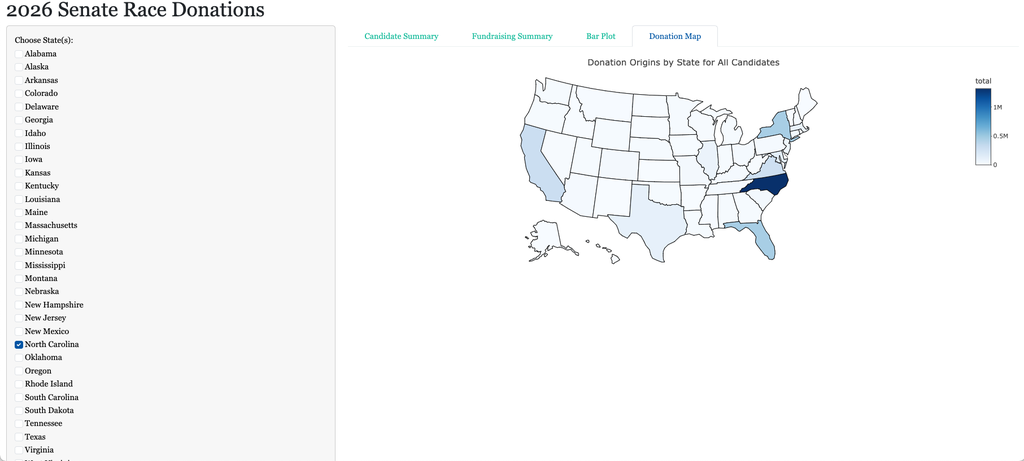

Example of a map that is rendered after candidates are selected, giving context to where donations are coming from.

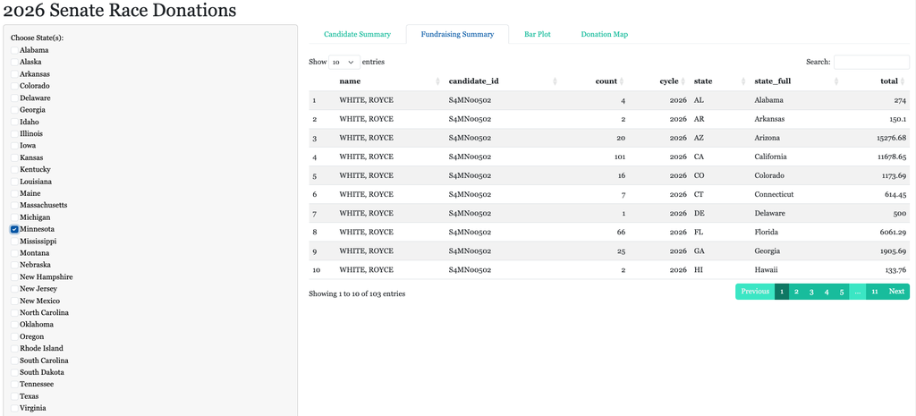

Shows data map is created from, providing the deeper dive on candidate stats and gives context on where donors originate from.

## 1.4 Statistical Analysis Inputs, Controls, and Outputs

Users, once they find the states they are interested in, have two ways to look at the data. They can look at the total funds raised and how much of that money came from pacs or large donors. And they can also see, on a map, exactly which states those donations came from.

Future functionality will allow users to see the breakout of where the money came from for each candidate, but now the heatmap is showing where donors are seeking to influence the overall race from.

To try and make the graphics most useful. The candidates that have raised no money are excluded. The dataframe is then recoded, and the pivot_longer function is used to make the data usable for graphing purposes.

```r
 df_long <- df |>
      filter(receipts > 1) |> #remove
      mutate(receipts = (receipts - (individual_itemized_contributions + other_political_committee_contributions))) |>
      pivot_longer(
        cols = c(receipts, individual_itemized_contributions, other_political_committee_contributions),
        names_to = "Type", values_to = "Amount"
      ) |>
      mutate(
        Type = recode(Type,
                      receipts = "Small-dollar donations, transfers, other donations",
                      individual_itemized_contributions = "Donations over $200",
                      other_political_committee_contributions = "PACs"
        ),
        name_party = paste0(name, " (", party, ")")
      )
```

[figure not shown]

We also created a regression analysis with boxplot showing donation by home state and party. In the future we will provide more documentation on errors and allow users to select individual candidates to hone in their analysis.

Sample code of the regression analysis:

```r
  output$model_summary <- renderPrint({
    df <- candidate_fundraising_df()
    req(nrow(df) > 0)

    # Create the home_state variable (in_state or out_of_state)
    df <- df |> mutate(candidate_state = substr(candidate_id, 3, 4))  # extract state code from candidate_id
    df <- df |> mutate(home_state = ifelse(state == candidate_state, "in_state", "out_of_state"))

    # Ensure 'home_state' and 'party' are factors for regression
    df <- df |> mutate(
      home_state = factor(home_state, levels = c("in_state", "out_of_state")),
      party = factor(party)
    )

    # Fit the linear regression model
    model <- lm(total ~ home_state + party, data = df)

    # Display the summary of the model (coefficients, p-values, etc.)
    summary(model)
  })
```

## 1.5 References

1. Theoretical Foundation for Degressive Proportionality in Apportionment Problems Journal of Political Economy link: https://www.jstor.org/stable/10.1086/670380 Summary: This paper develops a theoretical framework for degressive proportionality—a principle where representation (or resource allocation) increases with population size but at a diminishing rate. The authors argue that if individual utility functions are concave, utilitarian social welfare optimization favors degressive proportionality in collective decision-making (e.g., parliamentary seat allocation). The study uses mathematical modeling to link individual preferences to constitutional rules.

Relevance to Our Project:

-Hypothesis Support: The paper indirectly supports our hypothesis that donor geography influences candidate priorities. If political attention (like parliamentary representation) is degressively proportional to donor concentration, candidates may prioritize areas with dense donor clusters, even if those areas are out-of-state.

-Methodological Inspiration: The concavity assumption mirrors our planned analysis of donation patterns. For instance, we might expect candidates to disproportionately cater to high-donation ZIP codes, even if those areas represent a small fraction of their electorate.

-Visualization Parallels: The paper’s emphasis on mapping population-to-representation ratios aligns with our ZIP-level donor visualizations, which aim to reveal spatial biases in funding sources.

Gaps and Limitations:

-The study focuses on parliamentary apportionment, not campaign finance, so its direct applicability requires careful translation.

-It does not address dynamic or temporal aspects (e.g., how donation patterns evolve during an election cycle), which our app will tackle via the FEC API’s real-time data.

-The theoretical model assumes perfect data transparency, whereas our project must handle incomplete FEC records (e.g., unitemized donations).

Key Takeaway: This resource provides a conceptual foundation for analyzing how uneven donor distributions might skew candidate behavior, reinforcing the need for our app’s transparency tools.

2. FEC Data and API Best Practices Harvard Dataverse link: https://dash.harvard.edu/entities/publication/a580bb8b-bab5-443c-9c1e-6d3018b31aff Summary: This practical guide reviews challenges and opportunities when working with Federal Election Commission (FEC) data, including incomplete employer/demographic fields, API rate limits, and strategies for aggregating and visualizing donation records. It emphasizes the importance of handling “unitemized” donations (small contributions not individually reported) and leveraging the FEC’s bulk data options for efficiency.

Relevance to Our Project:

-Data Source Guidance: The paper directly addresses our primary data pipeline (FEC API), offering solutions for common pitfalls (e.g., missing employer fields, API pagination).

-Visualization Strategies: It recommends best practices for aggregating donation records—critical for our ZIP-level maps and bar charts of itemized vs. unitemized contributions.

-Ethical Considerations: The discussion on data incompleteness informs our app’s disclaimer about limitations (e.g., untraceable dark money).

Gaps and Limitations:

-The guide does not provide state- or Senate-specific analysis, leaving room for our app to fill a niche in visualizing statewide races.

-It lacks examples of interactive tools (like Shiny apps), which our project will deliver.

-Advanced statistical tests (e.g., regressions on donor concentration) are outside its scope but are part of our proposed features.

Key Takeaway: This resource is a technical roadmap for our data workflow, ensuring robust API queries and transparent handling of FEC data limitations. Its gaps highlight opportunities for our app to innovate in user-friendly, Senate-focused donor visualizations.

Together, these resources ground our project in theory (donor influence as a degressively proportional problem) and practice (FEC data challenges). However, they leave unmet needs—such as interactive, voter-facing tools for Senate races—that our Shiny app will address. By combining theoretical insights with API-driven transparency, we bridge a gap in political finance literacy.